# Reanalysis 2 - Outputs

David Henerson

14 February 2019

# Intro

After re-cleaning and wrangling the raw data in `reanalysis_1.Rmd`, I’m going to produce the plots and tables required for the Renfrewshire chapter in my thesis. There are three questions I want to answer for this. The first two will be answered in this file.

1. What percentage of the total amount of people receiving home care in each financial year get care during the SCS census week?
2. For individuals that don’t receive any home care during the census week,
1. Is there a difference in age and gender?
2. Is there a difference in the types of care they receive?
3. Is there a difference in the duration of their home care service?
4. Is there a difference in the weekly hours of home care they receive?
3. What percentage of the total amount of people receiving home care in each financial year get care during the last quarter of the year?

The first two explain themselves (I hope), the third is in response to the fact that the newest SCS is going to use a census quarter as opposed to a census week. Will be nice to see if there is good uplift. I’ll answer that question in a different file though.

## Packages

Load required packages

```r
library(tidyverse)
library(magrittr)
library(lubridate)
theme_set(theme_minimal(base_size = 16))
library(ggthemes)

#My own helper functions
source("Research/functions/my_datatable.R")
```

## Data

Load data. The `overall_ts` object was created in `reanalysis_1.Rmd`. I’m also loading in a vector containing the census dates in each year. These are already included as a variable in the data frame but are handy as a vector also. I’ll highlight where I use it later.

```r
load("Research/analysis_2019_feb/created_objects/data_frames/overall_ts.rds")

#A vector containing the census week dates
census_dates <- c(
  ymd(20060327), ymd(20070326), ymd(20080331), ymd(20090330), ymd(20100329),
  ymd(20110328), ymd(20120326), ymd(20130325), ymd(20140331), ymd(20150330),
  ymd(20160328))
```

# Plots and summaries

The first thing I want for output is a table with a summary of each year.

```r
overall_ts %>%
  #drop 05/06 - obeservations for one week only in this year
  filter(fin_year != "2005/06") %>%
  #drop rows that indicate a gap in care
  filter(receiving_care == TRUE) %>%
  group_by(fin_year) %>%
  #create summaries
  summarise(obs = n(),
            total = n_distinct(id),
            n_female = n_distinct(id[sex == "Female"]),
            n_male = n_distinct(id[sex == "Male"]),
            av_age = round(mean(age),1),
            sd_age = round(sd(age),1),
            pct_male = round(n_male/total*100, 1),
            pct_female = round(n_female/total*100, 1)) %>%
  #post summary wrangle - change every column to character
  mutate_all(., as.character) %>%
  #Add brackets to the percentage columns
  mutate_at(., vars(c(pct_male:pct_female)), function(x) x = str_c("(",x,")")) %>%
  #Now unite the sex and percent columns together
  unite(n_female, n_female, pct_female, sep = " ") %>%
  unite(n_male, n_male, pct_male, sep = " ") %>%
  #gather to long format
  gather(variable, value, obs:sd_age) %>%
  #and spread the financial year variables
  spread(fin_year, value) -> overall_desc
#Now factorise the variable column which will enable sorting
overall_desc$variable <- factor(overall_desc$variable,
                                levels = c("obs", "total", "n_female", "n_male", "av_age",
                                           "sd_age"),
                                labels = c("Observations", "N = ", "N Female (%)",
                                           "N Male (%)", "Mean age", "SD age"))
#Print it out
overall_desc %>%
  arrange(variable) %>%
  my_datatable(.)
```

|  | variable | 2006/07 | 2007/08 | 2008/09 | 2009/10 | 2010/11 | 2011/12 | 2012/13 | 2013/14 | 2014/15 | 2015/16 |
| --- | --- | --- | --- | --- | --- | --- | --- | --- | --- | --- | --- |
| 1 | Observations | 77554 | 79627 | 82765 | 83752 | 77734 | 69618 | 73287 | 82874 | 87071 | 91870 |
| 2 | N = | 2435 | 2486 | 2577 | 2577 | 2323 | 2262 | 2537 | 2799 | 2962 | 3106 |
| 3 | N Female (%) | 1709 (70.2) | 1725 (69.4) | 1736 (67.4) | 1736 (67.4) | 1591 (68.5) | 1523 (67.3) | 1657 (65.3) | 1831 (65.4) | 1945 (65.7) | 1982 (63.8) |
| 4 | N Male (%) | 726 (29.8) | 761 (30.6) | 841 (32.6) | 841 (32.6) | 732 (31.5) | 739 (32.7) | 880 (34.7) | 968 (34.6) | 1017 (34.3) | 1124 (36.2) |
| 5 | Mean age | 81.7 | 81.8 | 81.9 | 82.2 | 82.5 | 82.5 | 82.6 | 82.7 | 82.7 | 82.5 |
| 6 | SD age | 7.7 | 7.8 | 7.9 | 7.9 | 8 | 8.1 | 8.1 | 8 | 8 | 7.9 |

## Question 1

1. What percentage of the total amount of people receiving home care in each financial year get care during the SCS census week?

I want a summary of the individuals that receive *home care* services (including housing support and meals) in each week of the time series created in `reanalysis_1.Rmd`.

Firstly, I need to create a summary table

```r
overall_ts %>%
  #drop rows indicating a gap in care
  filter(receiving_care == TRUE) %>%
  group_by(fin_year, week) %>%
  #count number in and out of census
  count(any_in_cen) %>%
  #and the total for each year
  mutate(total = sum(n)) %>%
  ungroup %>%
  #add the SCS return figures to the row indicating the census week
  #using the vector of dates intiated in the load data chunk above
  mutate(scs = case_when(week == census_dates[1] ~ 1510,
                         week == census_dates[2] ~ 1520,
                         week == census_dates[3] ~ 1490,
                         week == census_dates[4] ~ 1520,
                         week == census_dates[5] ~ 1530,
                         week == census_dates[6] ~ 1290,
                         week == census_dates[7] ~ 1300,
                         week == census_dates[8] ~ 1410,
                         week == census_dates[9] ~ 1520,
                         week == census_dates[10] ~ 1760,
                         week == census_dates[11] ~ 1740),
         #calculate the difference between the SCS return and my count
         #for that week
         diff = total - scs) -> weekly_count

#Now add a count for unique individuals in financial year
overall_ts %>%
  #drop observations showing gaps in care
  filter(receiving_care == TRUE) %>%
  group_by(fin_year) %>%
  #count unique indiviudals
  summarise(annual_count = n_distinct(id)) %>%
  #and join to the weekly count
  left_join(weekly_count, .) %>%
  #keep annual count value only in the census week observation
  #make the rest NA - need this for the plot
  mutate(annual_count = if_else(!is.na(scs), annual_count, NA_integer_)) %>%
  #calculate the percentage captured in census week
  mutate(pct_week = round(total/annual_count * 100, 1)) %>%
  ungroup -> total_count
```

**EDIT**

**Rather than repeat a table an plot I am going to add in the answer to question 3 here**

First, add in the count of individuals in quarter 4 created in `reanlaysis_3.Rmd` and then join to the `total_count` object created in the chunk above.

```r
load("Research/analysis_2019_feb/created_objects/data_frames/quarterly_count.rds")
quarterly_count %>%
  select(-nn) %>%
  left_join(total_count, .) %>%
  mutate(quarter_4 = if_else(!is.na(scs), quarter_4, NA_integer_),
         q4_pct = if_else(!is.na(scs), q4_pct, NA_real_)) -> total_count
```

Now I can plot this table (after some more wrangling), I’ll print the table out later.

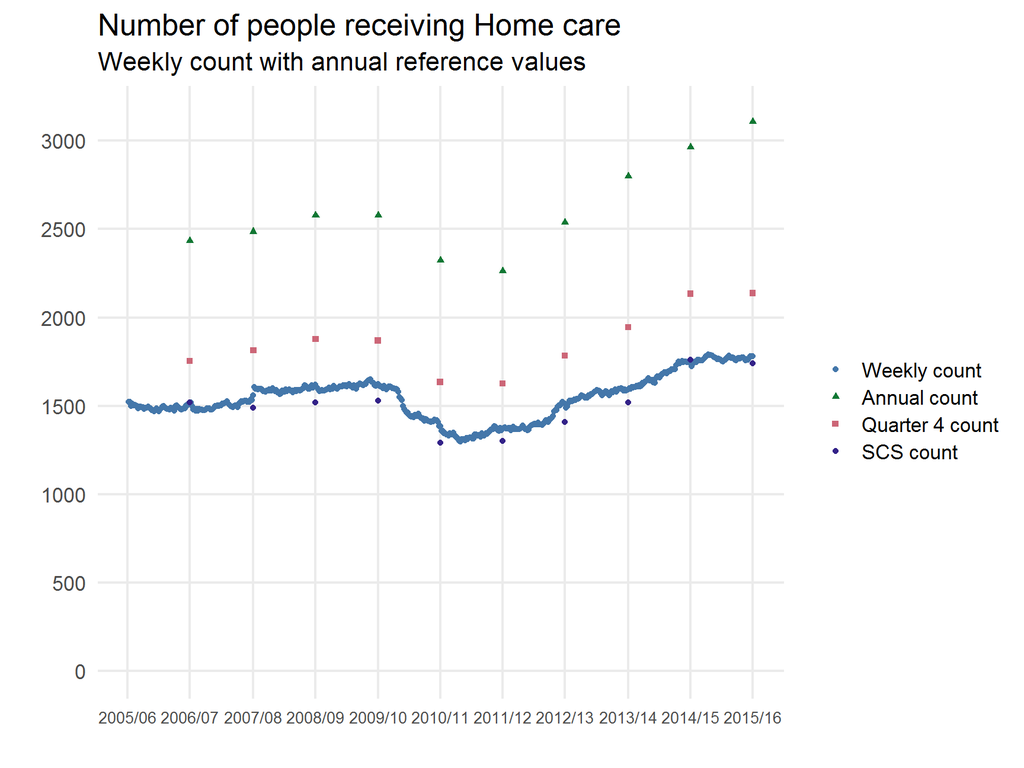

```r
total_count %>%
  #drop unneeded variables
  select(-fin_year, -diff, -pct_week, -n, -q4_pct) %>%
  #I have duplicated rows for total count as there is also a variable showing this figure
  #split by presence in census. right now I don't need this so will keep the firt row only
  filter(any_in_cen == TRUE) %>%
  #and drop the unneeded variable
  select(-any_in_cen) %>%
  #now gather into long format
  gather(lbl, value, total:quarter_4, -week) -> play_plot

#and factorise the labels - easier to plot now
play_plot$lbl <- factor(play_plot$lbl,
                        levels = c("total", "annual_count", "quarter_4", "scs"),
                        labels = c("Weekly count", "Annual count", "Quarter 4 count",
                                   "SCS count"))

play_plot %>%
  filter(week != ymd(20060327)) %>%
  ggplot(aes(week, value, shape = lbl, colour = lbl)) +
  geom_point(size = 1.5) +
  scale_y_continuous(limits = c(0, 3150),
                     breaks = scales::pretty_breaks()) +
  scale_x_date(breaks = census_dates,
               labels = c("2005/06", "2006/07", "2007/08", "2008/09",  "2009/10", "2010/11",
                          "2011/12", "2012/13", "2013/14", "2014/15", "2015/16")) +
  scale_colour_manual(values = c("#4477AA", "#117733", "#CC6677", "#332288")) +
  scale_shape_manual(values = c(16, 17, 15, 19)) +
  theme(axis.text.x = element_text(size = 10),
        panel.grid.minor = element_blank()) +
  labs(
    title = "Number of people receiving Home care",
    subtitle = "Weekly count with annual reference values",
    colour = "",
    shape = "",
    y = "",
    x = ""
  ) -> weekly_count_plot
weekly_count_plot
```

Have to say I am pretty happy with this!! My weekly count (blue) matches the Renfrewshire SCS return pretty well and we can see the count on any given week (and especially the census week) is about 60% of the total number of individuals that will get care over the course of the financial year. *edit - and we can also see that a count of indiviudals with care in quarter 4 of each finaincial year gives us about a 10% bump in numbers caught* I’ll print out the table.

```r
#similar wrangle as seen above in the overall summary table - not going to recomment the code here
total_count %>%
  filter(!is.na(scs)) %>%
  filter(week != ymd(20060327)) %>%
  select(-week, -any_in_cen, -n) %>%
  rename(`Financial Year` = fin_year,
         `Census week count` = total,
         `Quarter 4 count` = quarter_4,
         `% of annual count in Q4` = q4_pct,
         `Value returned to SCS` = scs,
         `Annual count` = annual_count,
         Difference = diff,
         `% of annual count in census` = pct_week) %>%
  mutate_at(., vars(c(2:8)), as.character) %>%
  gather(variable, value, 2:8) %>%
  spread(`Financial Year`, value) -> count_wide
count_wide$variable <- factor(count_wide$variable,
                              levels = c("Census week count", "Value returned to SCS",
                                         "Difference", "Annual count",
                                         "% of annual count in census",
                                         "Quarter 4 count", "% of annual count in Q4"))
count_wide %>%
  arrange(variable) %>%
  my_datatable(.)
```

|  | variable | 2006/07 | 2007/08 | 2008/09 | 2009/10 | 2010/11 | 2011/12 | 2012/13 | 2013/14 | 2014/15 | 2015/16 |
| --- | --- | --- | --- | --- | --- | --- | --- | --- | --- | --- | --- |
| 1 | Census week count | 1515 | 1560 | 1619 | 1623 | 1385 | 1373 | 1513 | 1594 | 1746 | 1779 |
| 2 | Value returned to SCS | 1520 | 1490 | 1520 | 1530 | 1290 | 1300 | 1410 | 1520 | 1760 | 1740 |
| 3 | Difference | -5 | 70 | 99 | 93 | 95 | 73 | 103 | 74 | -14 | 39 |
| 4 | Annual count | 2435 | 2486 | 2577 | 2577 | 2323 | 2262 | 2537 | 2799 | 2962 | 3106 |
| 5 | % of annual count in census | 62.2 | 62.8 | 62.8 | 63 | 59.6 | 60.7 | 59.6 | 56.9 | 58.9 | 57.3 |
| 6 | Quarter 4 count | 1754 | 1815 | 1877 | 1870 | 1635 | 1626 | 1784 | 1944 | 2134 | 2138 |
| 7 | % of annual count in Q4 | 72 | 73 | 72.8 | 72.6 | 70.4 | 71.9 | 70.3 | 69.5 | 72 | 68.8 |

## Question 2(i)

2. For individuals that don’t receive any home care during the census week,
1. Is there a difference in age and gender?

I am going to visualise using 2015/16 as a reference year to answer this.

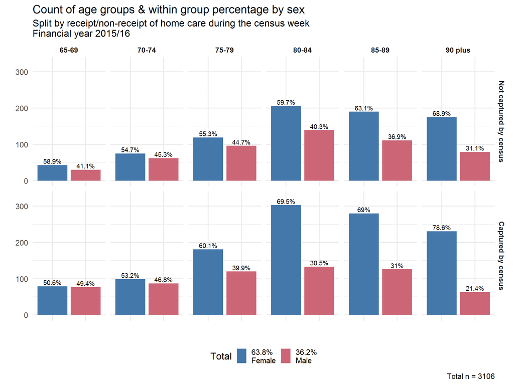

```r
overall_ts %>%
  filter(receiving_care == TRUE) %>%
  select(id, sex, age_grp, fin_year, any_in_cen) %>%
  distinct(id, fin_year, .keep_all = TRUE) %>%
  filter(fin_year != "2005/06") %>%
  filter(!is.na(sex)) %>%  #4 rows with missing values for sex
  group_by(fin_year, sex, age_grp, any_in_cen) %>%
  count %>%
  group_by(fin_year, age_grp, any_in_cen) %>%
  mutate(pct = round(n/sum(n) * 100, 1)) -> age_sex



age_sex %>%
  filter(fin_year == "2015/16") %>%
  ggplot(aes(sex, n, fill = sex)) +
  geom_col(position = "dodge") +
  geom_text(aes(label = paste0(pct,"%")), vjust = -0.3) +
  facet_grid(any_in_cen ~ age_grp,
             labeller = labeller(
               any_in_cen = as_labeller(c(`TRUE` = "Captured by census",
                                          `FALSE` = "Not captured by census")))) +
  scale_y_continuous(limits = c(0, 325),
                     breaks = scales::pretty_breaks()) +
  scale_fill_ptol(labels = c("63.8%\nFemale", "36.2%\nMale")) +
  theme(legend.position = "bottom",
        strip.text = element_text(size = 12, face = "bold"),
        axis.text.x = element_blank()) +
  labs(title = "Count of age groups & within group percentage by sex",
       subtitle = "Split by receipt/non-receipt of home care during the census week\nFinancial year 2015/16",
       x = "",
       y = "",
       fill = "Total",
       caption = "Total n = 3106") -> age_sex_plot
age_sex_plot
```

Here we see the overall distribution is pretty similar. The biggest discrepancies are in the 80-84 and 90 plus age groups where the percentage of females is higher in the group captured by the census. Although this is largest group, we are still talking about relatively small numbers and (as a rough guesstimate) 20 more women and 20 fewer men in the group not captured by the census would even things up somewhat.

I have only produced the plot for one year here. There is too much info to make this into a small multiple and in any case we replicate what is shown here with some variation reflecting the small numbers. I’m happy that there are no major differences by age or sex between those in/not in the census.

## Question 2(ii)

2. For individuals that don’t receive any home care during the census week,
2. Is there a difference in the types of care they receive?

I’d like to see how type of care breaks down by year. I’ll produce a table first. There are some small numbers here so I’ll code in some supression, any value below 30 will show as `<30`. I can still see zero values where nobody received any type of care. When creating the final table for the thesis I’ll be adding a footnote to mention that individuals can receive more than one type of care in any given year so column sums won’t equal total values. The good news (I think) is that there are always at least two rows with `<30` values so we can’t back calculate any specific `<30` value.

```r
overall_ts %>%
  filter(receiving_care == TRUE) %>%
  filter(fin_year != "2005/06") %>%
  group_by(fin_year) %>%
  summarise(Records = n(),
            N = n_distinct(id),
            Mainstream = n_distinct(id[mainstream > 0]),
            Reablement = n_distinct(id[reable > 0]),
            `Housing Support` = n_distinct(id[housing > 0]),
            `Extra Care Housing` = n_distinct(id[extra_housing > 0]),
            `Mental Health` = n_distinct(id[mh > 0]),
            `Overnight Services` = n_distinct(id[overnight > 0]),
            `Rapid Response` = n_distinct(id[rapid > 0]),
            `Meals Service` = n_distinct(id[meals > 0])) %>%
  ungroup %>%
  mutate_if(is.integer, function(x) x = if_else(x < 30 & x > 0, NA_integer_, x)) -> type_tab

type_tab %>%
  mutate_if(is.integer, as.character) %>%
  gather(variable, value, Records:`Meals Service`) %>%
  spread(fin_year, value) -> type_tab_print
type_tab_print$variable <- factor(type_tab_print$variable,
                                  levels = c("Records", "N", "Mainstream", "Meals Service",
                                             "Reablement", "Rapid Response",
                                             "Extra Care Housing", "Housing Support",
                                             "Overnight Services", "Mental Health"))
type_tab_print %>%
  arrange(variable) %>%
  mutate_if(is.character, function(x) x = replace_na(x, "<30")) %>%
  my_datatable(.)
```

|  | variable | 2006/07 | 2007/08 | 2008/09 | 2009/10 | 2010/11 | 2011/12 | 2012/13 | 2013/14 | 2014/15 | 2015/16 |
| --- | --- | --- | --- | --- | --- | --- | --- | --- | --- | --- | --- |
| 1 | Records | 77554 | 79627 | 82765 | 83752 | 77734 | 69618 | 73287 | 82874 | 87071 | 91870 |
| 2 | N | 2435 | 2486 | 2577 | 2577 | 2323 | 2262 | 2537 | 2799 | 2962 | 3106 |
| 3 | Mainstream | 2383 | 2367 | 2329 | 2278 | 2047 | 1757 | 1762 | 1998 | 2164 | 2244 |
| 4 | Meals Service | 0 | 331 | 958 | 958 | 900 | 857 | 846 | 923 | 985 | 1017 |
| 5 | Reablement | 0 | &lt;30 | &lt;30 | &lt;30 | &lt;30 | 344 | 930 | 871 | 895 | 930 |
| 6 | Rapid Response | 131 | 267 | 134 | 148 | &lt;30 | 181 | 254 | 197 | 182 | 123 |
| 7 | Extra Care Housing | 0 | &lt;30 | 73 | 102 | 101 | 100 | 110 | 101 | 120 | 118 |
| 8 | Housing Support | &lt;30 | &lt;30 | &lt;30 | &lt;30 | &lt;30 | &lt;30 | &lt;30 | &lt;30 | &lt;30 | &lt;30 |
| 9 | Overnight Services | 31 | 43 | 49 | 54 | 38 | 69 | 89 | 96 | 59 | 54 |
| 10 | Mental Health | &lt;30 | &lt;30 | &lt;30 | &lt;30 | &lt;30 | &lt;30 | &lt;30 | &lt;30 | &lt;30 | &lt;30 |

Given there are a few services with very small numbers I’ll drop them from the plot… (I need to redo the table taking into account those in/out of the census then some more wrangling to enable the plot)

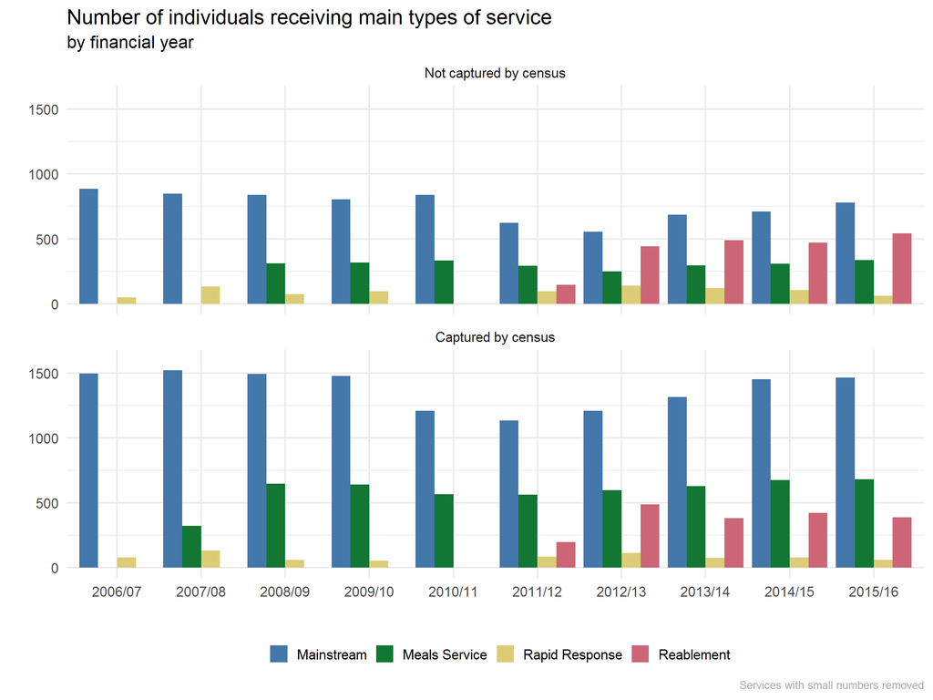

```r
overall_ts %>%
  filter(receiving_care == TRUE) %>%
  filter(fin_year != "2005/06") %>%
  #add in the extra group here
  group_by(fin_year, any_in_cen) %>%
  summarise(Records = n(),
            Total = n_distinct(id),
            Mainstream = n_distinct(id[mainstream > 0]),
            Reablement = n_distinct(id[reable > 0]),
            `Housing Support` = n_distinct(id[housing > 0]),
            `Extra Care Housing` = n_distinct(id[extra_housing > 0]),
            `Mental Health` = n_distinct(id[mh > 0]),
            `Overnight Services` = n_distinct(id[overnight > 0]),
            `Rapid Response` = n_distinct(id[rapid > 0]),
            `Meals Service` = n_distinct(id[meals > 0])) %>%
  ungroup %>%
  mutate_if(is.integer, function(x) x = if_else(x < 30 & x > 0, NA_integer_, x)) -> type_tab

type_tab %>%
  select(-Records, -Total) %>%
  gather(type, n, Mainstream:`Meals Service`, -fin_year) -> type_tab_long

type_tab_long %>%
  filter(type %in% c("Mainstream", "Meals Service", "Reablement",
                     "Rapid Response")) %>%
  ggplot(aes(fin_year, n, fill = type)) +
  geom_col(position = "dodge") +
  facet_wrap(~any_in_cen, ncol = 1,
             labeller = labeller(
               any_in_cen = as_labeller(c(`TRUE` = "Captured by census",
                                          `FALSE` = "Not captured by census")))) +
  scale_fill_ptol() +
  scale_y_continuous(limits = c(0, 1600),
                     breaks = scales::pretty_breaks()) +
  theme(legend.position = "bottom",
        plot.caption = element_text(size = 10, colour = "#AAAAAA")) +
  labs(title = "Number of individuals receiving main types of service",
       subtitle = "by financial year",
       x = "",
       y = "",
       fill = "",
       caption = "Services with small numbers removed") -> type_plot
type_plot
```

### Question 2(iii)

2. For individuals that don’t receive any home care during the census week,
3. Is there a difference in the duration of their home care service?

Ok,

For this plot I’m going to create a variable measuring the length of time an individual started receiving *any* form of home care to the census week in each financial year. By nature this creates some censoring (right-sided I think).

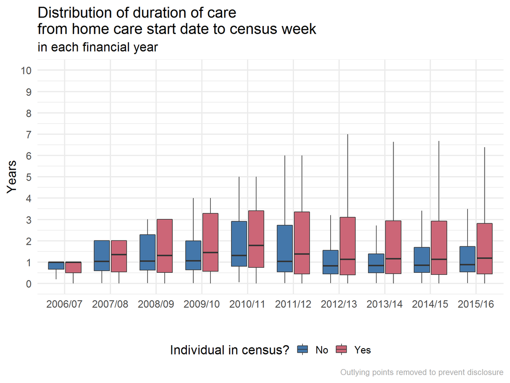

```r
overall_ts %>%
  mutate(dur = (start_date %--% cen_week)/dyears(1)) %>%
  filter(receiving_care == TRUE) %>%
  filter(fin_year != "2005/06") %>%
  distinct(id, fin_year, n_care_eps_year, .keep_all = TRUE) %>%
  ggplot(aes(fin_year, dur, fill = any_in_cen)) +
  geom_boxplot(outlier.shape = NA) +
  scale_fill_ptol(labels = c("No", "Yes")) +
  scale_y_continuous(breaks = scales::pretty_breaks(n = 11)) +
  theme(legend.position = "bottom",
        plot.caption = element_text(size = 10, colour = "#AAAAAA")) +
  labs(title = "Distribution of duration of care\nfrom home care start date to census week",
       subtitle = "in each financial year",
       x = "",
       y = "Years",
       fill = "Individual in census?",
       caption = "Outlying points removed to prevent disclosure") -> overall_dur_plot
overall_dur_plot
```

Notice median values are lower for those that are missed from the census. In every year around 50% of care is for people in the system for more than a year. How does that break down by care type?

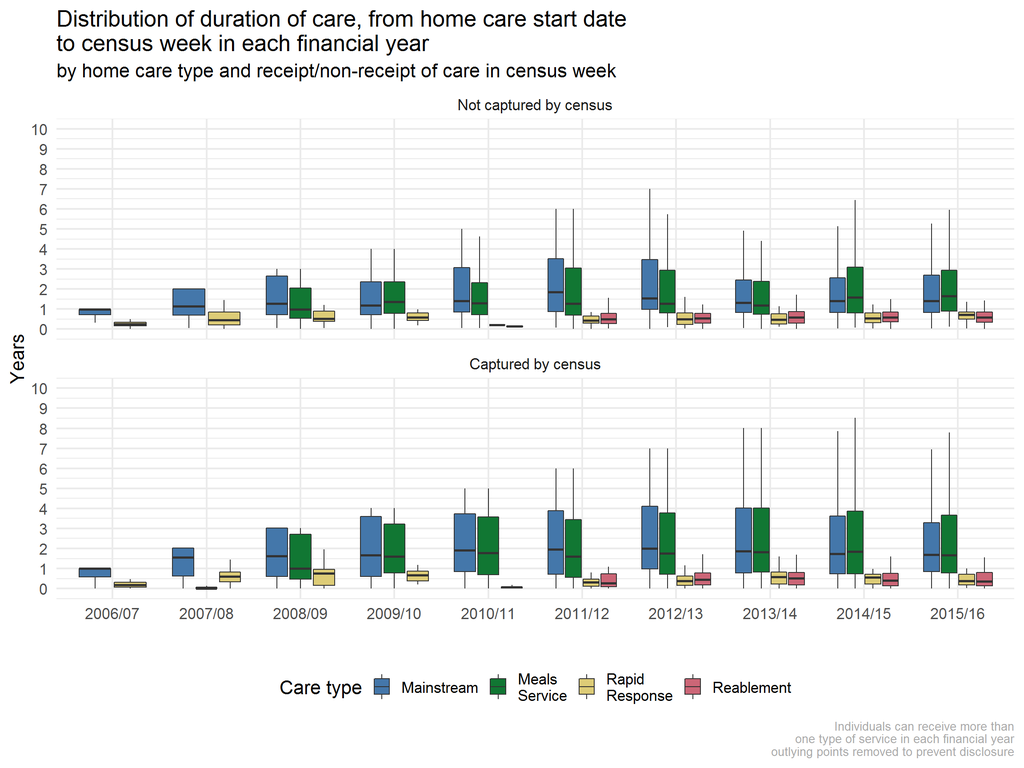

```r
overall_ts %>%
  filter(receiving_care == TRUE) %>%
  filter(fin_year != "2005/06") %>%
  distinct(id, fin_year, n_care_eps_year, .keep_all = TRUE) %>%
  select(id, fin_year, cen_week, any_in_cen, mainstream, reable,
         rapid, meals, receiving_care, n_care_eps_year,
         start_date, end_date) %>%
  mutate(dur = (start_date %--% cen_week)/dyears(1)) %>%
  gather(type, value, mainstream:meals) %>%
  arrange(id, fin_year, type) %>%
  filter(value > 0) %>%
  ggplot(aes(fin_year, dur, fill = type)) +
  geom_boxplot(outlier.shape = NA) +
  scale_y_continuous(breaks = scales::pretty_breaks(n = 12)) +
  scale_fill_ptol(labels = c("Mainstream", "Meals\nService",
                             "Rapid\nResponse", "Reablement")) +
  facet_wrap(~any_in_cen, nrow = 2,
             labeller = labeller(
               any_in_cen = as_labeller(c(`TRUE` = "Captured by census",
                                          `FALSE` = "Not captured by census")))) +
  theme(legend.position = "bottom",
        plot.caption = element_text(size = 10, colour = "#AAAAAA")) +
  labs(title = "Distribution of duration of care, from home care start date\nto census week in each financial year",
       subtitle = "by home care type and receipt/non-receipt of care in census week",
       x = "",
       y = "Years",
       fill = "Care type",
       caption = "Individuals can receive more than\none type of service in each financial year\noutlying points removed to prevent disclosure") -> type_dur_plot
type_dur_plot
```

So now we see lots more variation in teh duration of care. Where median values were around the one year mark above when we split by care type we see Mainstrean, and Meals have higher median values in both groups, whereas RR and Reablement typically last less than a year.

Finally, a last duration plot looking only at those *not* in the census. This time the measurement is from the *start of the financial year* to the date the care *terminated*.

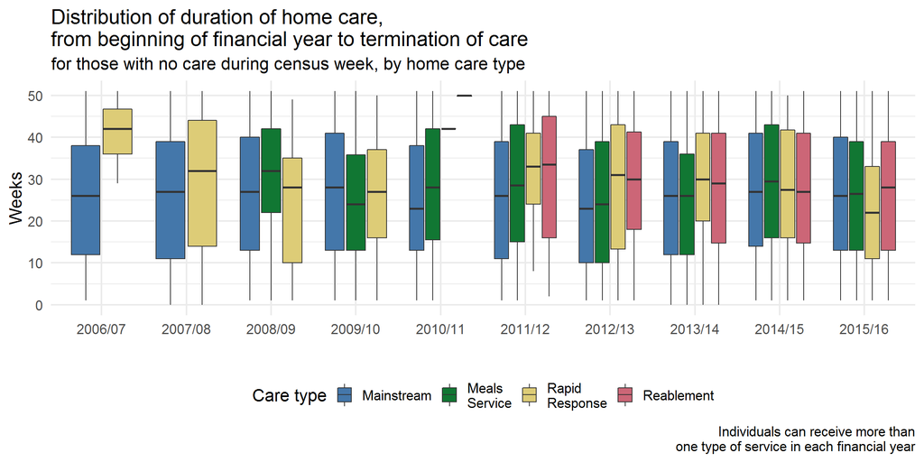

```r
overall_ts %>%
  filter(receiving_care == TRUE) %>%
  filter(fin_year != "2005/06") %>%
  filter(any_in_cen == FALSE) %>%
  distinct(id, fin_year, n_care_eps_year, .keep_all = TRUE) %>%
  select(id, fin_year, cen_week, any_in_cen, mainstream, reable,
         rapid, meals, receiving_care, n_care_eps_year,
         start_date, end_date) %>%
  mutate(dur = 52 -(end_date %--% cen_week)/dweeks(1)) %>%
  gather(type, value, mainstream:meals) %>%
  arrange(id, fin_year, type) %>%
  filter(value > 0) %>%
  ggplot(aes(fin_year, dur, fill = type)) +
  geom_boxplot(outlier.shape = NA) +
  scale_y_continuous(breaks = scales::pretty_breaks()) +
  scale_fill_ptol(labels = c("Mainstream", "Meals\nService",
                             "Rapid\nResponse", "Reablement")) +
  theme(legend.position = "bottom") +
  labs(title = "Distribution of duration of home care,\nfrom beginning of financial year to termination of care",
       subtitle = "for those with no care during census week, by home care type",
       x = "",
       y = "Weeks",
       fill = "Care type",
       caption = "Individuals can receive more than\none type of service in each financial year") -> no_cen_dur_plot
no_cen_dur_plot
```

Some variation where there are some small numbers but generally there is a normal distribution of length of care. This gives a bit more credence to my hunch. RR and reablement are short by design, the other 3 are long lasting types of care but stop randomly throughout the year.

## Question 2(iv)

2. For individuals that don’t receive any home care during the census week,
4. Is there a difference in the weekly hours of home care they receive?

First of all a look at the total number of weekly hours of care received. This is the average of the sum of mainstream + reablement + housing etc.etc. Meals are provided as n per week so aren’t included here (also I don’t have an accurate count - I just wanted to know they were getting any meals). As the total weekly hours can vary throughout the year I’m using the mean value. I’ve dropped some outliers in this plot.

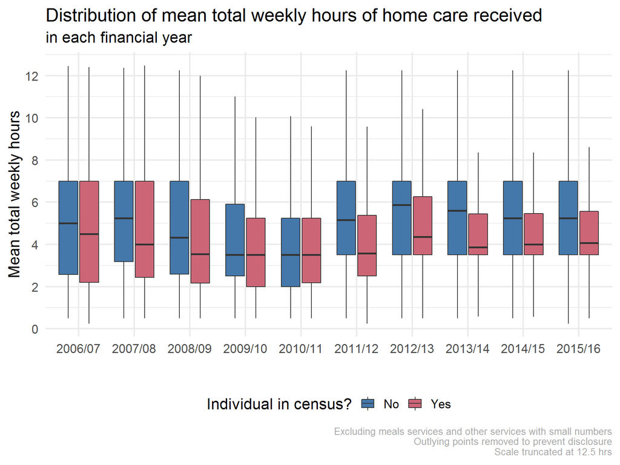

```r
overall_ts %>%
  filter(receiving_care == TRUE) %>%
  filter(fin_year != "2005/06") %>%
  filter(total < 56) %>%
  group_by(id, fin_year) %>%
  mutate(av_hrs = mean(total)) %>%
  select(id, fin_year, any_in_cen, mainstream, reable, rapid, total) %>%
  gather(type, value, mainstream:total) %>%
  filter(value != 0) %>%
  group_by(id, fin_year, type) %>%
  mutate(av_hrs = mean(value)) %>%
  ungroup %>%
  distinct(id, fin_year, type, .keep_all = TRUE) -> int_table

int_table %>%
  filter(type == "total") %>%
  filter(av_hrs <= 12.5) %>%
  ggplot(aes(fin_year, av_hrs, fill = any_in_cen)) +
  geom_boxplot(outlier.shape = NA) +
  scale_fill_ptol(labels = c("No", "Yes")) +
  scale_y_continuous(breaks = scales::pretty_breaks()) +
  theme(legend.position = "bottom",
        plot.caption = element_text(size = 10, colour = "#AAAAAA")) +
  labs(title = "Distribution of mean total weekly hours of home care received",
       subtitle = "in each financial year",
       x = "",
       y = "Mean total weekly hours",
       fill = "Individual in census?",
       caption = "Excluding meals services and other services with small numbers\nOutlying points removed to prevent disclosure\nScale truncated at 12.5 hrs") -> overall_hrs_plot
overall_hrs_plot
```

Now to split by care type

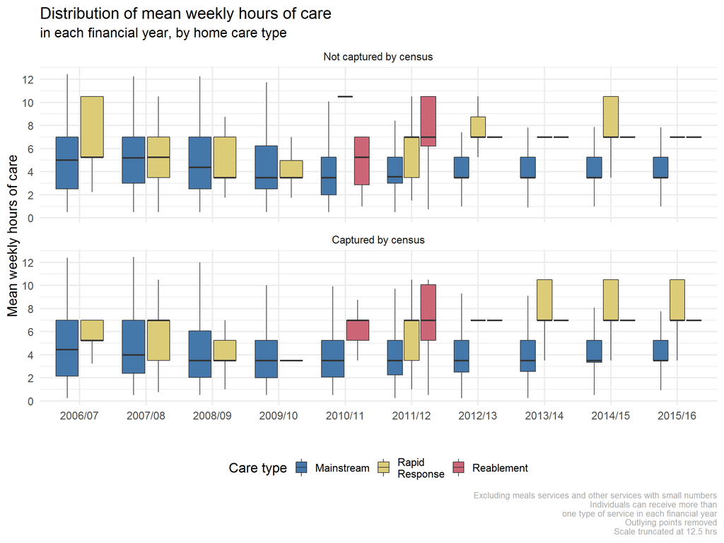

```r
int_table %>%
  filter(type != "total") %>%
  filter(av_hrs <=12.5) %>%
  ggplot(aes(fin_year, av_hrs, fill = type)) +
  geom_boxplot(outlier.shape = NA) +
  scale_y_continuous(breaks = scales::pretty_breaks()) +
  scale_fill_ptol(labels = c("Mainstream", "Rapid\nResponse", "Reablement")) +
  facet_wrap(~any_in_cen, nrow = 2,
             labeller = labeller(
               any_in_cen = as_labeller(c(`TRUE` = "Captured by census",
                                          `FALSE` = "Not captured by census")))) +
  theme(legend.position = "bottom",
        plot.caption = element_text(size = 10, colour = "#AAAAAA")) +
  labs(title = "Distribution of mean weekly hours of care",
       subtitle = "in each financial year, by home care type",
       x = "",
       y = "Mean weekly hours of care",
       fill = "Care type",
       caption = "Excluding meals services and other services with small numbers\nIndividuals can receive more than\none type of service in each financial year\nOutlying points removed\nScale truncated at 12.5 hrs") -> type_hrs_plot
type_hrs_plot
```

Confirmed here. Really interesting that from 2012/12 onwards the distribution of reablement is so tight we can’t even see a box. Over 50% of individuals receiving this service (in both groups) get an average of 7 hours of care per week (1 hr per day most likely which makes sense). Generally, RR and Reablement have higher weekly hours in both groups, whereas other services have broadly similar values in both groups.